# Week3 Mon Lab

Naomi

2023-01-26

# ESP 106 Lab 3

Monday, January 23, 2023

## Graphing

In this lab session, we will start by reading merging in data on economic development and indoor and outdoor air pollution. Then we will practice making some graphs with it.

### Question 1

Read in the three csv files: gdppercapitaandgini and airpollution

Both data sets are from Our World in Data: ourworldindata.org

- The GDP data set has GDP per capita and the GINI index (a measure of income inequality: https://en.wikipedia.org/wiki/Gini_coefficient)
- The air pollution data set has death rates from indoor and outdoor air pollution - units are in deaths per 100,000 people
  - Indoor air pollution is the **Household Air Pollution from Solid Fuels**
  - Outdoor air pollution is split into **Particulate Matter** and **Ozone**

gdppercapitaandgini and airpollution csv datasets are imported and renamed :

- gdppercapitaandgini becomes **gdpgini**
- airpollution becomes **apol**

```r
setwd("C:\\Users\\Benny Panjaitan\\Documents\\MS TTP UC Davis\\WINTER 2023\\ESP 106 Environmental Data Science")
apol <- read.csv("airpollution.csv")
gdpgini <- read.csv("gdppercapiandgini.csv")
```

```r
str(gdpgini)
```

```
## 'data.frame':    46942 obs. of  7 variables:
##  $ Entity                                                    : chr  "Abkhazia" "Afghanistan" "Afghanistan" "Afghanistan" ...
##  $ Code                                                      : chr  "OWID_ABK" "AFG" "AFG" "AFG" ...
##  $ Year                                                      : int  2015 1800 1801 1802 1803 1804 1805 1806 1807 1808 ...
##  $ Total.population..Gapminder..HYDE...UN.                   : num  NA 3280000 3280000 3280000 3280000 3280000 3280000 3280000 3280000 3280000 ...
##  $ Continent                                                 : chr  "Asia" "" "" "" ...
##  $ Gini.coefficient..World.Bank..2016..                      : num  NA NA NA NA NA NA NA NA NA NA ...
##  $ Output.side.real.GDP.per.capita..gdppc_o...PWT.9.1..2019..: num  NA NA NA NA NA NA NA NA NA NA ...
```

```r
dim(apol)
```

```
## [1] 6468    7
```

*The column names are long and cumbersome (because they contain information about units, etc.) - you might want to rename some of the columns to make them easier to work with.*

In that case, the columns are renamed to make them simpler.

```r
colnames(apol) <- c("Country","Code","Year","PM","Fuels","Ozone","Total")
colnames(gdpgini) <- c("Country","Code","Year","Population","Continent","GINI","GDP")
```

### Question 2

Choose two countries that you are interested in and make a plot showing the death rates from indoor air pollution and outdoor air pollution (summary of particulate matter and ozone) over time. Distinguish the countries using different colored lines and the types of pollution using different line types. Make sure to add a legend and appropriate titles for the axes and plot.

*Various country names can be seen using unique(x$Entity) where x is the data frame containing the air pollution data. Then create two new data frames that contain only the rows corresponding to each of the two countries you want to look at. Create a new column of total outdoor air pollution deaths by summing death rates from particulate matter and ozone. Use these to make your plot and add the lines you need. The y scale might have to be set manually to make sure the plot is wide enough to show both countries. It can be done by using the “ylim” argument in plot.*

Death caused by indoor pollution comes from Household Air Pollution from Solid Fuels under the column name of ‘**Fuels**’. Deaths caused by outdoor pollution are total of deaths caused by Particulate Matter and deaths caused by Ozone under the column names of ‘**PM**’ and ‘**Ozone**’.

```r
apol$Out <- apol$PM + apol$Ozone
```

Data from 2 particular countries are extracted:

1. **Indonesia** – Extracted by the code “IDN”, then kept into ‘idn’ data set
2. **Malaysia** – Extracted by the code “MYS”, then kept into ‘mys’ data set

```r
idn <- subset(apol, Code=="IDN")
mys <- subset(apol, Code=="MYS")
```

Graphic plot is made with condition below.

- **x axis** indicating **Year**
- **y axis** indicating **Number of deaths from Air Pollution**

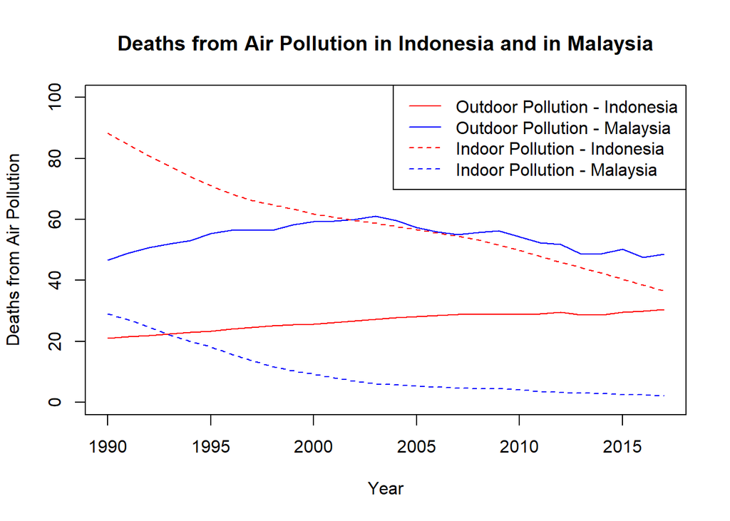

```r
plot(Out ~ Year, data=idn, type="l", main="Deaths from Air Pollution in Indonesia and in Malaysia", ylab="Deaths from Air Pollution", ylim=c(0,100), col="red")
lines(Out ~ Year, data=mys, col="blue")
lines(Fuels ~ Year, data=idn, col="red", lty=2)
lines(Fuels ~ Year, data=mys, col="blue", lty=2)
countries <- c('Outdoor Pollution - Indonesia', 'Outdoor Pollution - Malaysia', 'Indoor Pollution - Indonesia', 'Indoor Pollution - Malaysia')
legend('topright', countries, lty=c(1,1,2,2), col=c("red","blue"))
```

Each **countries** are distinguished by the **line color**:

- **Red line** indicating data from **Indonesia**
- **Blue line** indicating data from **Malaysia**

While each **type of air pollution** are distinguished by the **line types**:

- **Solid line** indicating **Outdoor Pollution**
- **Dash line** indicating **Indoor Pollution**

### Question 3

Merge the air pollution data with the GDP data using merge()

Merge is a function that combines data across two data frames by matching ID rows. By default merge will identify ID rows as those where column names are the same between data sets, but it is safer to specify the columns you want to merge by yourself using “by”. In our case, we want to merge both by country (either the “Entity” or “Code” columns) and year columns. Note that by default, the merge function keeps only the entries that appear in both data frames - that is fine for this lab. If you need for other applications, you can change using the all.x or all.y arguments to the function - check out the documentation at ?merge

Air Pollution data set (‘apol’) and GDP and GINI data set (‘gdpgini’) are merged into new data set entitled ‘**polgdp**’

```r
polgdp <- merge(apol, gdpgini)
```

### Question 4

Make a plot with two subplots - one showing a scatter plot between log of per-capita GDP (x axis) and indoor air pollution death rate (y axis) and one showing log of per-capita GDP (x axis) and outdoor air pollution (y axis). Make sure to add appropriate titles to the plots and axes. Use ylim to keep the range of the y axis the same between the two plots - this makes it easier for the reader to compare across the two graphs.

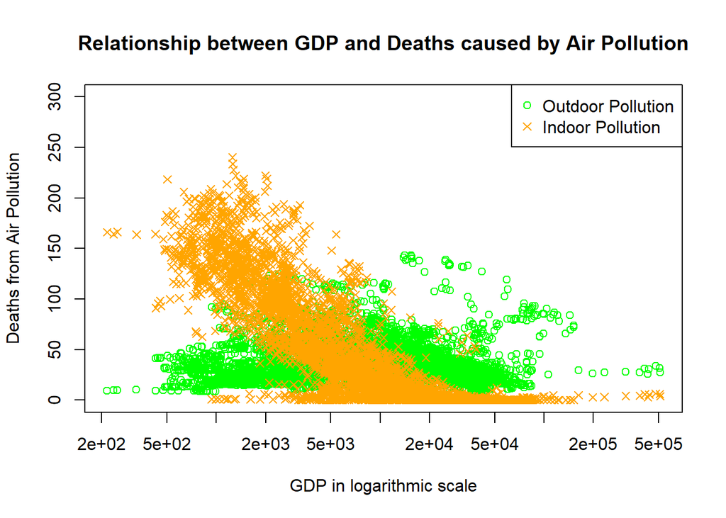

```r
plot(Out~GDP, data=polgdp, log="x", col="green", ylim=c(0,300), ylab="Deaths from Air Pollution", xlab="GDP in logarithmic scale", main="Relationship between GDP and Deaths caused by Air Pollution")
points(Fuels~GDP, data=polgdp, pch=4, col="orange")
pollution <- c ('Outdoor Pollution', 'Indoor Pollution')
legend('topright', pollution, pch=c(1,4), col=c("green","orange"))
```

Each **type of air pollution** are distinguished by the **point colors and types**:

- **Green dots** indicating **Outdoor Pollution**
- **Orange cross** indicating **Indoor Pollution**